# Visualization Assignment 2 - Movie Ratings

Working with Lorraine's Movie Ratings data, Here's what we know so far:

This assignment uses data obtained via MovieLens. The data sets were collected by the GroupLens Research Project at the University of Minnesota.

This data set consists of:

- 100,000 ratings (1-5) from 943 users on 1682 movies.
- Each user has rated at least 20 movies.
- Simple demographic info for the users (age, gender, occupation, zip)

The data was collected through the MovieLens web site (movielens.umn.edu) during the seven-month period from September 19th, 1997 through April 22nd, 1998.

## Importing Libraries and Loading the Data

```python
import pandas as pd
import numpy as np
import matplotlib.pyplot as plt
import seaborn as sns
```

```python
MovieRatings = pd.read_csv('Movie_Ratings.csv')
```

```python
pd.set_option('display.max_columns', 30)
```

```python
MovieRatings.head(3)
```

|  | Title | Movie Release Date | IMDb URL | Action | Adventure | Animation | Children | Comedy | Crime | Documentary | Drama | Fantasy | Film-Noir | Horror | Musical | Mystery | Romance | Sci-Fi | Thriller | War | Western | Rating | Interview Date | Age | Gender | Occupation | Zip | State | Latitude | … |
| --- | --- | --- | --- | --- | --- | --- | --- | --- | --- | --- | --- | --- | --- | --- | --- | --- | --- | --- | --- | --- | --- | --- | --- | --- | --- | --- | --- | --- | --- | --- |
| 0 | Toy Story (1995) | 01-Jan-1995 | http://us.imdb.com/M/title-exact?Toy%20Story%2... | 0 | 0 | 1 | 1 | 1 | 0 | 0 | 0 | 0 | 0 | 0 | 0 | 0 | 0 | 0 | 0 | 0 | 0 | 4 | 1997-11-27 | 28 | 0 | technician | 80525 | CO | 40.5384 | … |
| 1 | Toy Story (1995) | 01-Jan-1995 | http://us.imdb.com/M/title-exact?Toy%20Story%2... | 0 | 0 | 1 | 1 | 1 | 0 | 0 | 0 | 0 | 0 | 0 | 0 | 0 | 0 | 0 | 0 | 0 | 0 | 5 | 1998-01-06 | 44 | 0 | executive | 1581 | MA | 42.2679 | … |
| 2 | Toy Story (1995) | 01-Jan-1995 | http://us.imdb.com/M/title-exact?Toy%20Story%2... | 0 | 0 | 1 | 1 | 1 | 0 | 0 | 0 | 0 | 0 | 0 | 0 | 0 | 0 | 0 | 0 | 0 | 0 | 5 | 1998-04-03 | 26 | 1 | librarian | 22903 | VA | 38.0339 | … |

What is this data telling us?

We have almost a thousand different movie raters, thousands of movies which each occupy 1 or more genres, and demographic and location data on the raters.

### Some ideas of what we can explore through this data:

- Which genres get the highest ratings, which get the lowest
- Which occupations, age and location correlate with higher preference of genre
- How genres and rating preferences change over time
- How the time interval between interview date and movie release date affects the rating

We will break this analysis down by item of exploration. Each item with include a comprehansive visualization of the data, and a following statistical analysis to determine variable correlation, population parameters, and general indicators that will provide insight into the relationships between data variables and what those relationships could mean.

### Lets perform a few descriptive analyses on the whole ataset to get a feel of what it's telling us, and then dive into the visualizations and statistical processes

```python
len(MovieRatings)
```

```
96478
```

```python
MovieRatings.describe()
```

|  | Action | Adventure | Animation | Children | Comedy | Crime | Documentary | Drama | Fantasy | Film-Noir | Horror | Musical | Mystery | Romance | Sci-Fi | Thriller | War | Western | Rating | Age | Zip | Latitude | Longitude |
| --- | --- | --- | --- | --- | --- | --- | --- | --- | --- | --- | --- | --- | --- | --- | --- | --- | --- | --- | --- | --- | --- | --- | --- |
| count | 96478.000000 | 96478.000000 | 96478.000000 | 96478.000000 | 96478.000000 | 96478.000000 | 96478.000000 | 96478.000000 | 96478.000000 | 96478.000000 | 96478.000000 | 96478.000000 | 96478.000000 | 96478.000000 | 96478.00000 | 96478.000000 | 96478.000000 | 96478.000000 | 96478.000000 | 96478.000000 | 96478.000000 | 96478.000000 | 96478.000000 |
| mean | 0.254929 | 0.137430 | 0.036506 | 0.072618 | 0.300006 | 0.080122 | 0.007598 | 0.399107 | 0.013609 | 0.017268 | 0.052737 | 0.050022 | 0.052509 | 0.195039 | 0.12721 | 0.217345 | 0.094177 | 0.018398 | 3.534257 | 32.996497 | 52354.231815 | 39.227677 | -93.224326 |
| std | 0.435823 | 0.344303 | 0.187546 | 0.259509 | 0.458263 | 0.271483 | 0.086833 | 0.489717 | 0.115863 | 0.130270 | 0.223510 | 0.217991 | 0.223053 | 0.396233 | 0.33321 | 0.412441 | 0.292076 | 0.134386 | 1.126237 | 11.617245 | 30920.306674 | 4.798125 | 17.449464 |
| min | 0.000000 | 0.000000 | 0.000000 | 0.000000 | 0.000000 | 0.000000 | 0.000000 | 0.000000 | 0.000000 | 0.000000 | 0.000000 | 0.000000 | 0.000000 | 0.000000 | 0.00000 | 0.000000 | 0.000000 | 0.000000 | 1.000000 | 7.000000 | 1002.000000 | 21.348800 | -159.395400 |
| 25% | 0.000000 | 0.000000 | 0.000000 | 0.000000 | 0.000000 | 0.000000 | 0.000000 | 0.000000 | 0.000000 | 0.000000 | 0.000000 | 0.000000 | 0.000000 | 0.000000 | 0.00000 | 0.000000 | 0.000000 | 0.000000 | 3.000000 | 24.000000 | 22902.000000 | 35.866300 | -105.285100 |
| 50% | 0.000000 | 0.000000 | 0.000000 | 0.000000 | 0.000000 | 0.000000 | 0.000000 | 0.000000 | 0.000000 | 0.000000 | 0.000000 | 0.000000 | 0.000000 | 0.000000 | 0.00000 | 0.000000 | 0.000000 | 0.000000 | 4.000000 | 30.000000 | 55113.000000 | 40.046800 | -88.486200 |
| 75% | 1.000000 | 0.000000 | 0.000000 | 0.000000 | 1.000000 | 0.000000 | 0.000000 | 1.000000 | 0.000000 | 0.000000 | 0.000000 | 0.000000 | 0.000000 | 0.000000 | 0.00000 | 0.000000 | 0.000000 | 0.000000 | 4.000000 | 41.000000 | 80913.000000 | 42.279400 | -78.710600 |
| max | 1.000000 | 1.000000 | 1.000000 | 1.000000 | 1.000000 | 1.000000 | 1.000000 | 1.000000 | 1.000000 | 1.000000 | 1.000000 | 1.000000 | 1.000000 | 1.000000 | 1.00000 | 1.000000 | 1.000000 | 1.000000 | 5.000000 | 73.000000 | 99835.000000 | 64.854400 | -69.332800 |

This isn't telling us much, possibly because our data is all discrete. The counts just gives us the length of the dataframe and most of the statistics for the genres don't tell us much because the data is binary. Perhaps the mean gives us the percentage makeup of each genre? It tells us something useful about the Rating and Age: the mean rating is 3.5 with a standard deviation of 1, and the mean age is 33 years with a standard deviation of 11.6. The zip, latitude and longitude seem useless here.

## Age and Gender Composition

```python
MovieRatings['Gender'] = MovieRatings['Gender'].map({'M': 0, 'F': 1})
```

```python
%matplotlib inline
```

```
''
```

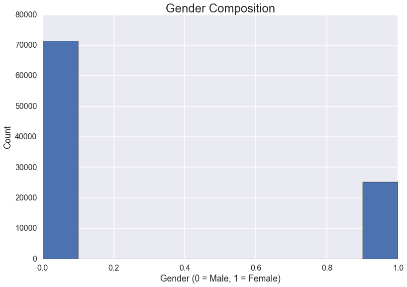

```python
sns.set_context("poster")
MovieRatings.Gender.hist()
plt.title('Gender Composition', size=24)
plt.ylabel('Count')
plt.xlabel('Gender (0 = Male, 1 = Female)')
;
```

It may not be the prettiest histogram, but it tells us something important. There are far more males, more than double by my estimate, than there are females in this movie review sample. Why is there such a skew is the sample? Surely women enjoy watching and reviewing films as much as men. And is there a single sample on this planet that includes more than two gender identities??

```python
MovieRatings.Gender.value_counts()
```

```
0    71362
1    25116
Name: Gender, dtype: int64
```

The hard numbers reinforce our histogram's findings

Now let's take a look at the age distribution of our sample.

[output not shown]

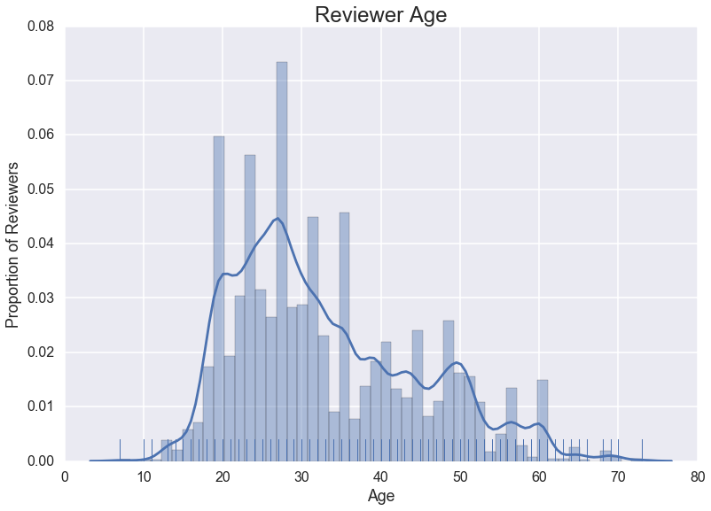

```python
sns.distplot(MovieRatings.Age, rug= True)
plt.title("Reviewer Age", fontsize=24)
plt.ylabel('Proportion of Reviewers')
plt.xlabel('Age');
```

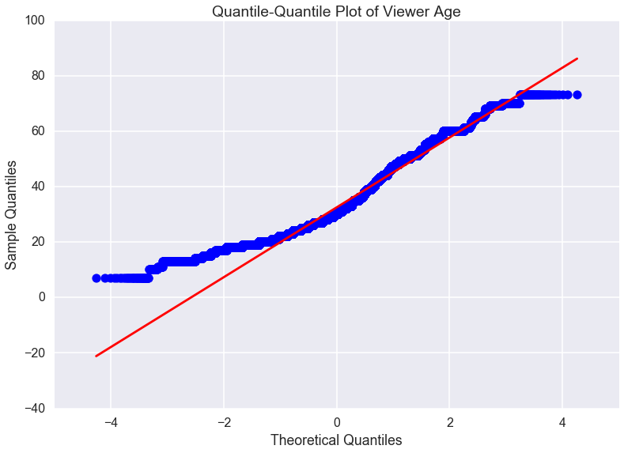

```python
import statsmodels.api as sm

sm.qqplot(MovieRatings.Age, line='q')
plt.title('Quantile-Quantile Plot of Viewer Age');
```

# Genre Counts

Lets get a count of our Genres. Below is a straightforward method of obtaining the counts of all our movie genres, and we will save them to variables in case we want to analyze or visualize them.

```python
TAction = MovieRatings.Action.sum()
TAction
```

```
24595
```

```python
TAdventure = MovieRatings.Adventure.sum()
TAdventure
```

```
13259
```

```python
TAnimation = MovieRatings.Animation.sum()
TAnimation
```

```
3522
```

```python
TChildren= MovieRatings.Children.sum()
TChildren
```

```
7006
```

```python
TComedy= MovieRatings.Comedy.sum()
TComedy
```

```
28944
```

```python
TCrime= MovieRatings.Crime.sum()
TCrime
```

```
7730
```

```python
TDocumentary= MovieRatings.Documentary.sum()
TDocumentary
```

```
733
```

```python
TDrama= MovieRatings.Drama.sum()
TDrama
```

```
38505
```

```python
TFantasy= MovieRatings.Fantasy.sum()
TFantasy
```

```
1313
```

```python
TFilm_Noir= MovieRatings['Film-Noir'].sum()
TFilm_Noir
```

```
1666
```

```python
THorror= MovieRatings.Horror.sum()
THorror
```

```
5088
```

```python
TMusical= MovieRatings['Musical'].sum()
TMusical
```

```
4826
```

```python
TMystery= MovieRatings.Mystery.sum()
TMystery
```

```
5066
```

```python
TRomance= MovieRatings.Romance.sum()
TRomance
```

```
18817
```

```python
TSciFi = MovieRatings['Sci-Fi'].sum()
TSciFi
```

```
12273
```

```python
TThriller= MovieRatings.Thriller.sum()
TThriller
```

```
20969
```

```python
TWar= MovieRatings.War.sum()
TWar
```

```
9086
```

```python
TWestern= MovieRatings.Western.sum()
TWestern
```

```
1775
```

This is an okay way to get an idea of which genres occur more frequently, if you have the time to look through them and sort them. A slightly better approach would be to take the sum (or count of 1) and divide by the total movies in this dataset to get a proportion.

The best way to get an idea of which genres occur more frequently is to visualize each occurence. In this case, we will use a barplot.

```python
TGenres = pd.Series([TAction, TAdventure, TAnimation, TChildren, TComedy, TCrime, TDocumentary, TDrama,
                    TFantasy, TFilm_Noir, THorror, TMusical, TMystery, TRomance, TSciFi, TThriller, TWar, TWestern],
                   index = ['Action', 'Adventure', 'Animation', 'Children', 'Comedy', 'Crime', 'Documentary', 'Drama',
                    'Fantasy', 'Film_Noir', 'Horror', 'Musical', 'Mystery', 'Romance', 'SciFi', 'Thriller', 'War', 'Western'])
```

```python
TGenres = TGenres.sort_values(ascending=False)
```

```python
TGenres.head()
```

```
Drama       38505
Comedy      28944
Action      24595
Thriller    20969
Romance     18817
dtype: int64
```

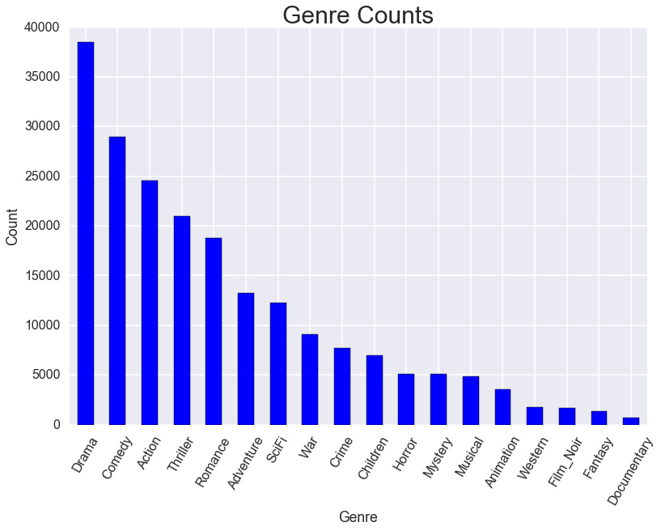

```python
Genre_Count = TGenres.plot.bar()
plt.title('Genre Counts', size=30)
plt.xlabel('Genre')
plt.ylabel('Count')

for label in Genre_Count.get_xticklabels():
    label.set_rotation(60);
```

Now that's what we want to see! Drama has the highest count, followed by Comedy and Action. This is an example of a useful bar plot, that can be interpreted by just about anyone.

## Which Genres get the Highest and Lowest Ratings

I want to plot the genres by defining them as a category. I don't see how that is possible with the dataframe showing each genre as a binary variable. I want to put the genres into one variable, set it as a category, and visualize it against my other variables such as Ratings.

```python
Genre_Rating = pd.melt(MovieRatings, id_vars=['Rating'], value_vars=['Action', 'Adventure', 'Animation', 'Children', 'Comedy',
                                                     'Crime', 'Documentary', 'Drama', 'Fantasy', 'Film-Noir', 'Horror',
                                                     'Musical', 'Mystery', 'Romance', 'Sci-Fi', 'Thriller', 'War',
                                                     'Western'], var_name='Genre')
```

```python
Genre_Rating.value = Genre_Rating.Genre.value_counts()
Genre_Rating.head()
```

|  | Rating | Genre | value |
| --- | --- | --- | --- |
| 0 | 4 | Action | NaN |
| 1 | 5 | Action | NaN |
| 2 | 5 | Action | NaN |
| 3 | 5 | Action | NaN |
| 4 | 4 | Action | NaN |

```python
for i in ['Genre']:
    Genre_Rating[i] = Genre_Rating[i].astype('category')
```

```python
Genre_Rating.dtypes
```

```
Rating       int64
Genre     category
value      float64
dtype: object
```

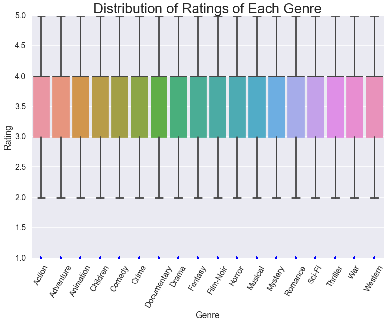

```python
Genre_Ratings = sns.boxplot(x = 'Genre', y = 'Rating', data = Genre_Rating)
plt.title('Distribution of Ratings of Each Genre', size=28)
for label in Genre_Ratings.get_xticklabels():
    label.set_rotation(60);
```

```python
len(Genre_Rating)/len(MovieRatings)
#Great. it just replicated the same values of MovieRating over and over.
```

```
18.0
```

Our attempt to melt the data into one accurate column has failed, so we cannot make a box plot out of our data that will tell us anything interesting.

## What Occupation Correlates with Movie Preference, Ratings

```python
for i in ['Occupation']:
    MovieRatings[i] = MovieRatings[i].astype('category')
```

```python
MovieRatings.dtypes
```

```
Title                          object
Movie Release Date             object
IMDb URL                       object
Action                          int64
Adventure                       int64
Animation                       int64
Children                        int64
Comedy                          int64
Crime                           int64
Documentary                     int64
Drama                           int64
Fantasy                         int64
Film-Noir                       int64
Horror                          int64
Musical                         int64
Mystery                         int64
Romance                         int64
Sci-Fi                          int64
Thriller                        int64
War                             int64
Western                         int64
Rating                          int64
Interview Date                 object
Age                             int64
Gender                          int64
Occupation                   category
Zip                           float64
State                          object
Latitude                      float64
Longitude                     float64
Date_Interval         timedelta64[ns]
dtype: object
```

```python
np.unique(MovieRatings.Occupation).ravel()
```

```
array(['administrator', 'artist', 'doctor', 'educator', 'engineer',
       'entertainment', 'executive', 'healthcare', 'homemaker', 'lawyer',
       'librarian', 'marketing', 'none', 'other', 'programmer', 'retired',
       'salesman', 'scientist', 'student', 'technician', 'writer'], dtype=object)
```

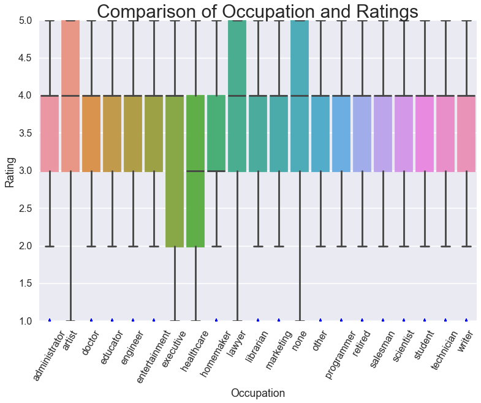

```python
sns.set_context("poster")
Occupation_Rating = sns.boxplot(x = 'Occupation', y = 'Rating', data = MovieRatings)
plt.title('Comparison of Occupation and Ratings', size=30)
plt.xlabel('Occupation')
plt.ylabel('Rating')

for label in Occupation_Rating.get_xticklabels():
    label.set_rotation(60);
```

What's the problem here? Well there are many problems. To start off, if we have too many categories, our box plot is just going to look crappy, as it does here. No one wants to read through all those Occupation names, and the boxes are smooshed together too tightly.

There's a bigger issue here though. Our Rating data is discrete and narrow (between 1 and 5), so all of our box plots will probably be the same dimension. Maybe one or two will be above or below another box plot. But they will almost always have the median, the IQ range will always be the same, and there will always be outlier poitns at y=1. Our box plot is also doing something interesting where it looks like boxes are overlaid on top of each other? I don't know anyting about this. Maybe the plot doesn't have enough space. Maybe the IQ range is actually larger on those data points. That explanation could make sense because as we can see, most of these boxes don't have their median outlined by the bar (remember the mean is around 3.5?). Perhaps as a result of our narrow ratings options, box plots just can't adequately plot against it.

## What Age Correlates with Movie Preference, Ratings

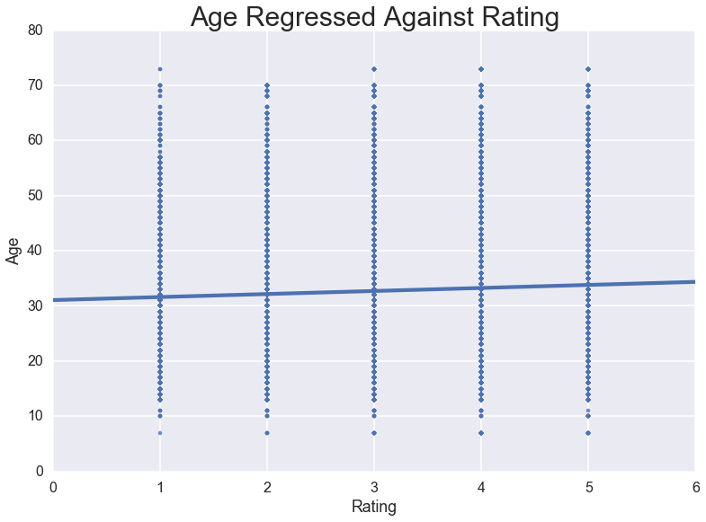

```python
reg = sns.regplot(x= 'Rating', y= 'Age', data= MovieRatings)
plt.title('Age Regressed Against Rating', size=30);
```

Like most of the plots thus far, it looks awkward. But it tells us something a little interesting: there seems to be a slight trend toward higher age associated with higher movie ratings. Although the trend is weak, this is the sort of finding that we're looking for from a visualization. This visualization could suggest to us that we want to model a linear regression against the data to prove or disprove that age is correlated with higher movie ratings.

Now let's try to see the density of that data more closely

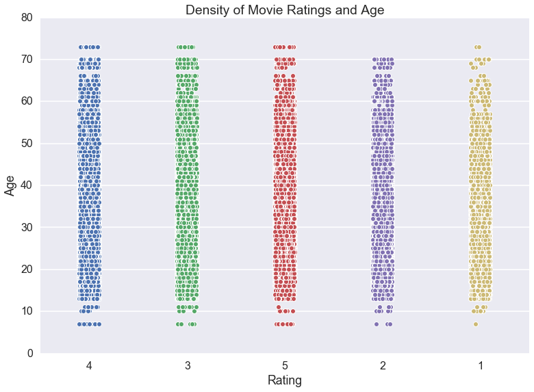

```python
sns.set_context("poster")
sns.stripplot(x= 'Rating', y= 'Age', data= MovieRatings, jitter=True)
plt.title('Density of Movie Ratings and Age');
```

WELL AT LEAST IT LOOKS PRETTY

Interestingly there are also some odd gaps in the age of the reviewers. That could tell us something about the locations the surveyor(s) went to acquire this data, if we wanted to look into it. This plot has also given me an idea. I've already recognized the ratings variable to be discrete, but I think I should also recognize it as categorical. Perhaps with this I can make a box and whiskers plot using my ratings data on the x-axis.

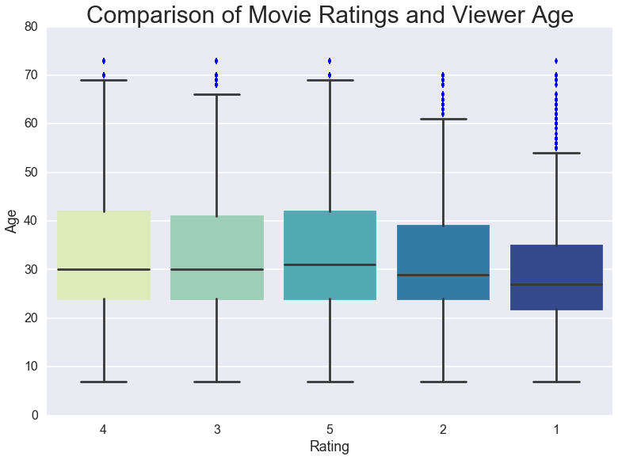

```python
sns.boxplot(x = 'Rating', y = 'Age', data = MovieRatings, palette="YlGnBu")
#Let's not forget to make our plots colorblind friendly :)
plt.title('Comparison of Movie Ratings and Viewer Age', size=30)
plt.xlabel('Rating')
plt.ylabel('Age');
```

Nice! I've finally gotten a useful box and whiskers plot out of my data. Now I can plot the jittered data on top of it to get a good look at my data density and distribution all together.

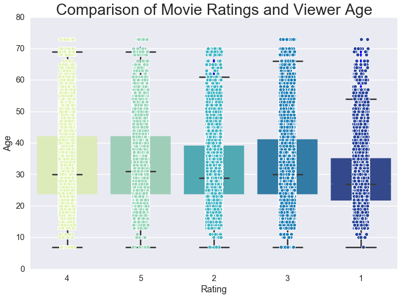

```python
sns.boxplot(x = 'Rating', y = 'Age', data = MovieRatings, notch=True, palette="YlGnBu")
plt.title('Comparison of Movie Ratings and Viewer Age', size=30)
sns.stripplot(x= 'Rating', y= 'Age', data= MovieRatings, jitter=True, palette="YlGnBu")
plt.xlabel('Rating')
plt.ylabel('Age');
```

Well this just looks overwhelming, but hey I can always use this method in the future, probably with a smaller dataset.

So what can we take away from our box plots? Let's looks at the box plot above WITHOUT the jitter to avoid getting a headache. It appears that the median and IQ range of age goes up as ratings go up, and down as ratings goes down. This reflects the regression line that we saw previously over our data, suggesting that higher age and higher ratings are positively correlated. One thing I don't like about these box plots is that it is not ordered by Rating. In fact, I don't even know what it is ordered by. This is something I should look into for future plots that I make.

## How do Genre and Rating Preferences Change Over Time

```python
MovieRatings2 = MovieRatings.groupby('Movie Release Date').median()
MovieRatings2.head(3)
```

| Movie Release Date | Action | Adventure | Animation | Children | Comedy | Crime | Documentary | Drama | Fantasy | Film-Noir | Horror | Musical | Mystery | Romance | Sci-Fi | Thriller | War | Western | Rating | Age | Gender | Zip | Latitude | Longitude |
| --- | --- | --- | --- | --- | --- | --- | --- | --- | --- | --- | --- | --- | --- | --- | --- | --- | --- | --- | --- | --- | --- | --- | --- | --- |
| 1922-01-01 | 0 | 0 | 0 | 0 | 0 | 0 | 0 | 0 | 0 | 0 | 1 | 0 | 0 | 0 | 0 | 0 | 0 | 0 | 4 | 34 | 0 | 44265 | 40.45980 | -84.43850 |
| 1926-01-01 | 0 | 0 | 0 | 0 | 0 | 0 | 0 | 1 | 0 | 0 | 0 | 0 | 0 | 0 | 0 | 0 | 0 | 0 | 3 | 27 | 0 | 47713 | 38.45400 | -94.31110 |
| 1930-01-01 | 0 | 0 | 0 | 0 | 0 | 0 | 0 | 1 | 0 | 0 | 0 | 0 | 0 | 0 | 0 | 0 | 0 | 0 | 4 | 52 | 0 | 48213 | 38.99685 | -85.44695 |

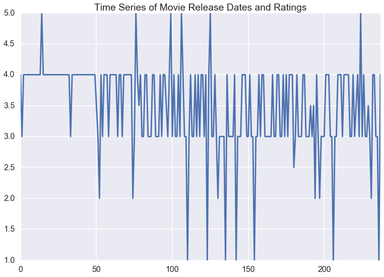

```python
sns.tsplot(data=MovieRatings2['Rating'])
plt.title('Time Series of Movie Release Dates and Ratings')
;
```

Why is this line plot so messy? because we're essentially plotting categorical data against date-time data. I don't imagine that I'll get a good time series visualization out of this dataset, unfortunately.

## Summarizing Our Findings

Here are my takeaways so far from visualizing this dataset in various contexts: